# 商管程式設計（109-1）

# 第二次期中考

## 國立臺灣大學資訊管理學系

請至 PDOGS（http://pdogs.ntu.im/judge/）為第一、二、三、四題各上傳一份Python 3.5 原始碼（以複製貼上原始碼的方式上傳）。每位學生都要上傳自己寫的解答。不接受紙本繳交；不接受遲交。

所有的分數都根據程式運算的正確性給分。PDOGS 會直譯並執行你的程式、輸入測試資料，並檢查輸出的答案的正確性。一筆測試資料佔 2 分。在所有的題目中，你都可以使用任何方法（包括課堂上沒教過的）。但你**不能 import 任何套件**。

這次的考試時間為 2020 年 11 月 23 日上午 9 點 10 分 00 秒至 2020 年 11 月 23 日下午 12 點 10 分 00 秒，共 180 分鐘。

# 第一題

（22%） 我們以一個有四個元素的 List 代表一個線段。一個由 （x1, y1） 到 （x2, y2） 的線段表示為`[x1, y1, x2, y2]`。一個圖形是很多線段構成的 List，也就是 List 中包其他的 List。舉例而言，以下三個線段：

- （0, 0） 到 （1, 0）
- （1, 0） 到 （1, 1）
- （1, 1） 到 （0, 0）

可以表示成：`[[0, 0, 1, 0], [1, 0, 1, 1], [1, 1, 0, 0]]`。也就是說，我們定義了一個 List，這個 List 中共有三個 List，分別是 `[0, 0, 1, 0]`、`[1, 0, 1, 1]`、`[1, 1, 0, 0]`。

這樣的圖形，可以用 `plotlines` 畫出:

```
import matplotlib.pyplot as plt

def plotlines(linelist, canvas=[-2, 2, -2, 2], finalize=True):
    plt.figure(figsize=(5, 5))
    plt.axis(canvas)
    for aline in linelist:
        plt.plot([aline[0], aline[2]], [aline[1], aline[3]],
                 linestyle='-', marker='o', color='b')
    plt.draw()
    plt.pause(.01)
    if finalize:
        plt.show()
```

例如:

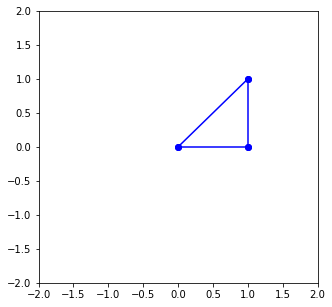

除了把圖形畫出來，另一個表示圖形的方式是用`printlines`把所有的線段座標印出來。

以下是一個小型的範例：

```
def printlines(linelist):
    for i, aline in enumerate(linelist):
        print("Line%d: %0.3f %0.3f %0.3f %0.3f" %
              (i, aline[0], aline[1], aline[2], aline[3]))

printlines(lines)
```

```
Line0: 0.000 0.000 1.000 0.000
Line1: 1.000 0.000 1.000 1.000
Line2: 1.000 1.000 0.000 0.000
```

由於 PDOGS 無法驗證 `plotlines` 所輸出的圖形是否正確，因此本題驗證正確性的方式為將一個圖形以 `printlines` 輸出，讓 PDOGS 確認這個圖形是否正確。

寫一個名叫 `plotmirror` 的函數，這個函數可以讓圖形對指定的水平線或垂直線鏡射。這個函數應該要長的像這樣：

```
def plotmirror(linelist, horv="h", loc=0):
    # 定義你的函數

    return afigure
```

這個函數的傳入值 linelist 為一個圖形，horv 設定是對水平線 （h） 或垂直線 （v） 鏡射, loc 設定這條線的位置。例如 horv = "h", loc = 3。表示對 $y = 3$ 這條水平線鏡射圖形。最後傳回一個新的圖形。

如果我們要對 $x = -0.2$ 的垂直線鏡射，那就該:

```
fig2 = plotmirror(lines, "v", -0.2)
plotlines(fig2)
printlines(fig2)
```

鏡射效果應該要如下圖中所示，紅色虛線構成的原始圖形，對 x = -0.2 的紅色垂直虛線鏡射後變為藍色線段構成的圖形。

注意：下圖中的紅色虛線僅作為鏡射示意使用，實際使用 `plotline` 函數時不會畫出

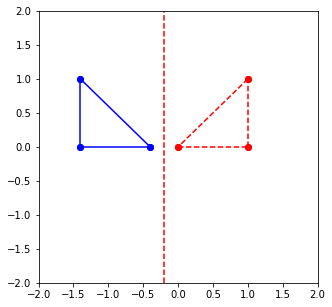

```
Line0: -0.400 0.000 -1.400 0.000
Line1: -1.400 0.000 -1.400 1.000
Line2: -1.400 1.000 -0.400 0.000
```

如果我們要對 $y = -0.2$ 的水平線鏡射，那就:

```
fig2 = plotmirror(lines, "h", -0.2)
plotlines(fig2)
printlines(fig2)
```

鏡射效果應該要如下圖中所示，紅色虛線構成的原始圖形，對 $y = -0.2$ 的紅色水平虛線鏡射後變為藍色線段構成的圖形。

注意:下圖中的紅色虛線僅作為鏡射示意使用，實際使用 `plotline` 函數時不會畫出

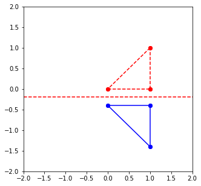

```
Line0: 0.000 -0.400 1.000 -0.400
Line1: 1.000 -0.400 1.000 -1.400
Line2: 1.000 -1.400 0.000 -0.400
```

## 輸入輸出格式

系統將會提供鏡射設定與測試圖形。你的程式應該在取得這些資料後呼叫`plotmirror`，取得鏡射後的圖形，並用`printlines`將結果輸出。

系統提供圖形時，所有座標值與位移量都應在 $[-2, 2]$ 中（介於 $-2$ 與 $2$ 之間，包含端點），系統給定的線段不一定會構成封閉圖形，鏡射線有可能穿過系統給定的圖形。每個圖形最少有一條線，最多的線條數量沒有限制。但測資中一個圖形不會超過 $100$ 條線。第一行輸入代表第一條線，第二行輸入代表第二條線，依此類推，每行輸入皆為四個實數，以半形逗點分隔，前兩個數字代表線段起點的 X 軸與 Y 軸座標，後兩個數字代表線段終點的 X 軸與 Y 軸座標。如果一行的輸入為「LINESTOP」，則代表所有的線段已經輸入完畢，下一行依序是 horv 與 loc 的設定（以半形逗點分隔）。

舉例而言，如果輸入是：

```
0,0,1,0
1,0,1,1
1,1,0,0
LINESTOP
h,-0.2
```

那輸出是：

```
Line0: 0.000 -0.400 1.000 -0.400
Line1: 1.000 -0.400 1.000 -1.400
Line2: 1.000 -1.400 0.000 -0.400
```

如果輸入是:

```
0,0,1,0
1,0,1,1
1,1,0,0
LINESTOP
v,-0.2
```

那輸出是:

```
Line0: -0.400 0.000 -1.400 0.000
Line1: -1.400 0.000 -1.400 1.000
Line2: -1.400 1.000 -0.400 0.000
```

如果輸入是:

```
0,0,1,0
LINESTOP
v,0
```

那輸出是:

```
Line0: 0.000 0.000 -1.000 0.000
```

如果輸入是:

```
0,0,1,0
LINESTOP
h,0
```

那輸出是:

```
Line0: 0.000 0.000 1.000 0.000
```

如果輸入是:

```
0,0,1,0
0,0,-1,0
1,0,1,1
LINESTOP
h,-0.5
```

那輸出是:

```
Line0: 0.000 -1.000 1.000 -1.000
Line1: 0.000 -1.000 -1.000 -1.000
Line2: 1.000 -1.000 1.000 -2.000
```

如果輸入是:

```
0,0,1,0
0,0,-1,0
1,0,1,1
LINESTOP
v,-0.5
```

那輸出是:

```
Line0: -1.000 0.000 -2.000 0.000
Line1: -1.000 0.000 0.000 0.000
Line2: -2.000 0.000 -2.000 1.000
```

# 第二題

（24%） 我們時常要處理雜亂的文字資料，面對這些既繁冗又無趣的勘誤，我們可以透過程式進行處理。現在我們要針對一段文字內容進行格式統一的處理，讀取多行文字（直到「INPUTSTOP」）。對這些文字處理後輸出。進行的處理包含:

- 去除頭尾的空白。
- 將這段文字中成對出現的半形雙引號 `"` 改成 `「` 與 `」` 。每一行中先出現的成對半形雙引號 `"`，會先被配對成一組，每一行輸入獨立判斷。如果最後有引號無法配對，則保留無法配對的引號，不做任何處理。
- 將多個連續空白縮減成一個空白，輸入不會有 tab 字元。
- 半形逗點 「,」、冒號 「:」、句號 「.」後面需要有一個空白，但前面不能有空白。但如果這些標點符號出現在某行輸入的行尾，則後面不應有空白。注意: 不論文本內容是否通順或是標點符號使用方式是否正確，你的程式只需依照上述規則處理即可。
- 本題中只需處理半形逗點 「,」、冒號 「:」、句號 「.」這三種英文標點符號的前後空白，以及雙引號「"」的配對，其餘的標點符號不需處理。

## 輸入輸出格式

系統將會提供多行字串。你的程式應該在取得這些字串後依照題目要求進行處理，並將處理後的字串輸出。

系統提供的每行字串可能包含中文、英文、數字以及標點符號。如果一行的輸入為「INPUTSTOP」，則代表所有字串已經輸入完畢。

舉例而言，如果輸入是：

```
美國總統選戰結果陷於膠著，進入冗長的法律戰。回顧大選前夕，美國白宮發表"川普論中國"文集，在"川普"總統首任屆滿之"際再度抨擊中共，
出版'川普論中國:美國優先'（Trump    on China:     Putting America First）網路版電子書，內容匯集川普總統以及高級官員的八篇對中政策演說文稿，具體呈現川普政府對中策略輪廓。
Both of the state's Senate seats were on the ballot this year ,   and one of them is already headed to a runoff ,    according to NBC News,    while the other may be   , too   , if Republican Sen   .    David Perdue stays below the 50 percent threshold needed to win outright under state law.
INPUTSTOP
```

那輸出是：

```
美國總統選戰結果陷於膠著，進入冗長的法律戰。回顧大選前夕，美國白宮發表「川普論中國」文集，在「川普」總統首任屆滿之"際再度抨擊中共，
出版'川普論中國: 美國優先'（Trump on China: Putting America First）網路版電子書，內容匯集川普總統以及高級官員的八篇對中政策演說文稿，具體呈現川普政府對中策略輪廓。
Both of the state's Senate seats were on the ballot this year, and one of them is already headed to a runoff, according to NBC News, while the other may be, too, if Republican Sen. David Perdue stays below the 50 percent threshold needed to win outright under state law.
```

舉例而言，如果輸入是：

```
"新冠"追蹤項目"的數據顯示，美國近期每周的檢測數增加12%，但病例數增加的速率是40%。
其中一個可能的原因是，由於步入冬季、氣溫下降，人們更常在室內而不是室外聚會社交，不良的通風環境使得病毒傳播加快。
INPUTSTOP
```

那輸出是:

```
「新冠」追蹤項目"的數據顯示，美國近期每周的檢測數增加12%，但病例數增加的速率是40%。
其中一個可能的原因是，由於步入冬季、氣溫下降，人們更常在室內而不是室外聚會社交，不良的通風環境使得病毒傳播加快。
```

舉例而言，如果輸入是：

```
PlayStation 5      and Xbox Series X stock is out once again at Walmart stores online.
 Out as in – gone, quickly , in the blink of an eye this afternoon.
INPUTSTOP
```

那輸出是:

```
PlayStation 5 and Xbox Series X stock is out once again at Walmart stores online.
Out as in - gone, quickly, in the blink of an eye this afternoon.
```

舉例而言，如果輸入是：

```
新台幣4月底開始升破30元整數關卡，10月以後，又升破29元，
11月6日盤中升破28.5元，市場所謂的"彭淮南防線"，
並在本月幾度於盤中站上28.4字頭。
The biggest issue   ,   it would appear, with the sales of the PlayStation 5 and Xbox Series X on Walmart’s webpage today was the data entry process    .
INPUTSTOP
```

那輸出是:

```
新台幣4月底開始升破30元整數關卡，10月以後，又升破29元，
11月6日盤中升破28. 5元，市場所謂的「彭淮南防線」，
並在本月幾度於盤中站上28. 4字頭。
The biggest issue, it would appear, with the sales of the PlayStation 5 and Xbox Series X on Walmart’s webpage today was the data entry process.
```

舉例而言，如果輸入是：

```
CMBC報導，舒默在紐約一場記者會中表示說   :   「「昨晚，他們已同意坐下來（磋商），幕僚將在今日或明日展開談判，看看我們能否達成良好的紓困方案。」"
INPUTSTOP
```

那輸出是:

```
CMBC報導，舒默在紐約一場記者會中表示說: 「「昨晚，他們已同意坐下來（磋商），幕僚將在今日或明日展開談判，看看我們能否達成良好的紓困方案。」"
```

舉例而言，如果輸入是：

```
非營利組織《消費者報告》表示 : "Model Y可靠度遠低於平均水準，因此消費者報告無法推薦。」該雜誌指出是車體和烤漆等品質問題。
Verizon and Apple Announce "5G Fleet Swap" to Promote Upgrade to iPhone 12
INPUTSTOP
```

那輸出是:

```
非營利組織《消費者報告》表示: "Model Y可靠度遠低於平均水準，因此消費者報告無法推薦。」該雜誌指出是車體和烤漆等品質問題。
Verizon and Apple Announce 「5G Fleet Swap」 to Promote Upgrade to iPhone 12
```

# 第三題

（32%） 處理資料檔時常會需要知道一些基本的資訊，比如說某個欄位是數值資料 （numerical），例如氣溫、身高或是體重等等；或是類別資料 （categorical），例如手機品牌、衣服花色等等。然而由文字檔讀取資料時，通常缺乏各欄位的描述。本題將要透過程式的方式，自動找出一些重要的資料檔基本描述。為了簡化問題，我們假設處理的資料檔沒有表頭，也就是讀入的文字檔由第一行開始就是資料。資料欄位以逗點分隔，忽略前後多餘空白字元，且沒有科學符號表示的數字 （如 `-1.23e-4`）。以下是我們需要的基本資訊

- 欄位為 numerical 或 categorical
- 每個欄位的最大長度
- 如為數值欄位，這個欄位的數值位數（小數點前有幾位數）與小數點後數值位數的最大值。

以下是這些基本資訊的判斷方式。

#### 1.欄位為 numerical 或 categorical （對應的指令為 `TYPE`）

如果一個欄位的所有資料都可以透過 `float()` 轉換為數字，則該欄位為 numerical。反之，只要該欄位中有任何一筆資料無法透過 `float()` 轉換為數字，則該欄位為categorical。

#### 2.每個欄位的最大長度 （對應的指令為 MAXLEN）

一個欄位中所有資料的最大（不含前後多餘空白）字串長度。

#### 3.欄位的最大數值位數 （對應的指令為 MAXNUMLEN）

如某欄位為類別資料，則該欄位數值位數為 $0$。如為數值資料，一筆資料的數值位數是這筆資料小數點前有幾位數。一個欄位所有資料的數值位數的最大值即為這個欄位的數值位數。下表是一些資料的數值位數。注意 `-.234` 的數值位數為 $1$，主要是這樣的數字原意應為 `-0.234`。

| 資料 | 數值位數 | 小數點後數值 | 字串長度 |
| --- | --- | --- | --- |
| 1234 | 4 | 0 | 4 |
| Apple | 0 | 0 | 5 |
| -.234 | 1 | 3 | 5 |
| 11.33 | 2 | 2 | 5 |
| 123.456 | 3 | 3 | 7 |
| 0.234 | 1 | 3 | 5 |
| 0.0 | 1 | 1 | 3 |
| 3. | 1 | 1 | 2 |

#### 4.欄位的最大小數點後數值位數 （對應的指令為 MAXDECPLACE）

如某欄位為類別資料，則該欄位小數點後數值位數 $0$。如為數值資料，一筆資料的小數點後數值位數是這筆資料在小數點後有幾位數。一個欄位所有資料的小數點後數值位數的最大值即為這個欄位的小數點後數值位數。參見上表的範例。注意 `3.` 的小數點後數值位數為 $1$，主要是這樣的數字原意應為 `3.0`。

這邊舉個例子說明本題的資料檔案解讀方式 (注意: 實際的資料檔案中沒有標註欄位編號，從第一行開始就是資料):

| 欄位 0 | 欄位 1 | 欄位 2 | 欄位 3 | ... | 欄位 13 | 欄位 14 |
| --- | --- | --- | --- | --- | --- | --- |
| 842517 | M | 20.57 | 17.77 | ... | 0.0 | 3. |
| 1659 | F | 21.5 | ha | ... | 0.0 | 5.1 |

下表則是顯示上面例子的各項基本資訊

|  | 欄位 0 | 欄位 1 | 欄位 2 | 欄位 3 | ... | 欄位 13 | 欄位 14 |
| --- | --- | --- | --- | --- | --- | --- | --- |
| TYPE | numerical | categorical | numerical | categorical | ... | numerical | numerical |
| MAXLEN | 6 | 1 | 5 | 5 | ... | 3 | 3 |
| MAXNUMLEN | 6 | 0 | 2 | 0 | ... | 1 | 1 |
| MAXDECPLACE | 0 | 0 | 2 | 0 | ... | 1 | 1 |

## 輸入輸出格式

讀取的第一行為資料檔位置，檔案內容為 $n$ 行資料，每行資料包含 $m$ 個欄位，每個欄位以半形逗點分隔， $1 \leq n \leq 40 $、$1 \leq m \leq 40 $。

`注意: 請使用「cp950」的編碼格式讀取檔案。`

第二行為一個字串，表示所要輸出的基本資訊，不同的字串對應到不同的輸出內容。第二行可能的輸入有 `TYPE` （欄位為 numerical 或 categorical）、 `MAXLEN` （每個欄位的最大長度）、 `MAXNUMLEN` （欄位的最大數值位數）、 `MAXDECPLACE` （欄位的最大小數點後數值位數）。

輸出時將每一筆資料按照 `欄位Index: 基本資訊` 的格式輸出。注意：`欄位Index` 後面的 `冒號`應先接一個`空白`，再接上題目所要求輸出的`基本資訊`。

`本題的 Sample 所使用到的sample data 跟題目一起放在NTU Cool，請同學到NTU Cool下載`

舉例而言，如果輸入是：

```
/var/www/html/judge/data/PBC109-1/midterm2/midterm2_q3_sample1.txt
TYPE
```

那輸出是:

```
0: numerical
1: categorical
2: numerical
3: numerical
4: numerical
5: numerical
6: numerical
7: numerical
8: numerical
9: numerical
10: numerical
11: numerical
12: numerical
13: numerical
14: numerical
```

如果輸入是:

```
/var/www/html/judge/data/PBC109-1/midterm2/midterm2_q3_sample2.txt
MAXLEN
```

那輸出是:

```
0: 6
1: 1
2: 5
3: 5
4: 5
5: 4
6: 7
7: 7
8: 6
9: 7
10: 6
11: 7
12: 6
13: 3
14: 2
```

如果輸入是:

```
/var/www/html/judge/data/PBC109-1/midterm2/midterm2_q3_sample2.txt
MAXNUMLEN
```

那輸出是:

```
0: 6
1: 0
2: 2
3: 0
4: 3
5: 4
6: 1
7: 3
8: 1
9: 1
10: 1
11: 1
12: 1
13: 1
14: 1
```

如果輸入是:

```
/var/www/html/judge/data/PBC109-1/midterm2/midterm2_q3_sample2.txt
MAXDECPLACE
```

那輸出是:

```
0: 0
1: 0
2: 2
3: 0
4: 1
5: 0
6: 5
7: 5
8: 4
9: 5
10: 4
11: 5
12: 4
13: 1
14: 1
```

# 第四題

（34%） 讀入一個算式，輸出這個算式的中文說法。算式的中文說法指的是如何用中文說出一個算式。比如說 `2+3*4/2=8` 的中文說法為`二加三乘以四除以二等於八`。所有算式的數字以及運算完的結果為 0 至 99 的整數，運算子有加「+」、減「-」、乘以「*」、除以「/」、等於「=」。

## 輸入輸出格式

讀取一個算式 (算式中不會包含空白字元)，輸出這個算式的中文說法。本題中不需檢查算式的正確性。

所有算式的數字以及運算完的結果為 0 至 99 的整數，因此不需考慮百、千、萬等等。

輸出時請使用以下的中文數字: 零、一、二、三、四、五、六、七、八、九、十。

舉例而言，如果輸入是:

```
2+3*4/2=8
```

那輸出是

```
二加三乘以四除以二等於八
```

如果輸入是

```
23+12-4=31
```

那輸出是

```
二十三加十二減四等於三十一
```

如果輸入是

```
11+22+33-33=33
```

那輸出是

```
十一加二十二加三十三減三十三等於三十三
```

如果輸入是

```
1*1*1*1=1
```

那輸出是

```
一乘以一乘以一乘以一等於一
```

如果輸入是

```
1-1=0
```

那輸出是

```
一減一等於零
```

如果輸入是

```
99*0+99*99-99*99+99=99
```

那輸出是

```
九十九乘以零加九十九乘以九十九減九十九乘以九十九加九十九等於九十九
```